# Lecture 15 - Data Transformation 3

2022-11-03

## Packages for this lecture

```r
library(tidyverse)
library(babynames)
library(nycflights13)
```

## So far in Data Transformation

- Introduction to data transformation
- Dplyr package functions
  - `select()`
  - `filter()`
  - `summarize()`
  - `arrange()`
  - Piping `%>%`
  - Combining with ggplot
  - `group_by`

## Today

```r
weather %>%
  group_by(month) %>%
  summarize(mean = mean(temp, na.rm = TRUE),
            std_dev = sd(temp, na.rm = TRUE))
```

```
## # A tibble: 12 × 3
##    month  mean std_dev
##    <int> <dbl>   <dbl>
##  1     1  35.6   10.2
##  2     2  34.3    6.98
##  3     3  39.9    6.25
##  4     4  51.7    8.79
##  5     5  61.8    9.68
##  6     6  72.2    7.55
##  7     7  80.1    7.12
##  8     8  74.5    5.19
##  9     9  67.4    8.47
## 10    10  60.1    8.85
## 11    11  45.0   10.4
## 12    12  38.4    9.98
```

```r
diamonds %>%
  group_by(cut) %>%
  summarize(avg_price = mean(price))
```

```
## # A tibble: 5 × 2
##   cut       avg_price
##   <ord>         <dbl>
## 1 Fair          4359.
## 2 Good          3929.
## 3 Very Good     3982.
## 4 Premium       4584.
## 5 Ideal         3458.
```

```r
babynames %>%
  group_by(sex) %>%
  summarize(total = sum(n))
```

```
## # A tibble: 2 × 2
##   sex       total
##   <chr>     <int>
## 1 F     172371079
## 2 M     175749438
```

Use ungroup to remove grouping criteria from a data frame.

```r
babynames %>%
  group_by(sex) %>%
  ungroup() %>%
  summarize(total = sum(n))
```

```
## # A tibble: 1 × 1
##       total
##       <int>
## 1 348120517
```

## Your turn

- Display the ten most popular name and sex combinations. (Compute popularity as the total number of children with a given name and sex.)
- Use group_by() to calculate the total number of children born for every year.
- Plot the results as a line graph: year vs. total.

## `mutate()`

*What was the top ranked name for each year?*

We can obtain the rank using `min_rank()`

```r
babynames %>%
  mutate(rank = min_rank(desc(prop)))
```

```r
babynames %>%
  mutate(rank = min_rank(desc(prop)))
```

```
## # A tibble: 1,924,665 × 6
##     year sex   name          n   prop  rank
##    <dbl> <chr> <chr>     <int>  <dbl> <int>
##  1  1880 F     Mary       7065 0.0724    14
##  2  1880 F     Anna       2604 0.0267   709
##  3  1880 F     Emma       2003 0.0205  1131
##  4  1880 F     Elizabeth  1939 0.0199  1192
##  5  1880 F     Minnie     1746 0.0179  1427
##  6  1880 F     Margaret   1578 0.0162  1683
##  7  1880 F     Ida        1472 0.0151  1897
##  8  1880 F     Alice      1414 0.0145  2039
##  9  1880 F     Bertha     1320 0.0135  2279
## 10  1880 F     Sarah      1288 0.0132  2387
## # … with 1,924,655 more rows
```

```r
weather <- weather %>%
 mutate(temp_in_C = (temp - 32) / 1.8)
```

```r
weather %>%
  group_by(month) %>%
  summarize(mean_temp_in_F = mean(temp, na.rm = TRUE),
            mean_temp_in_C = mean(temp_in_C, na.rm = TRUE))
```

```
## # A tibble: 12 × 3
##    month mean_temp_in_F mean_temp_in_C
##    <int>          <dbl>          <dbl>
##  1     1           35.6           2.02
##  2     2           34.3           1.26
##  3     3           39.9           4.38
##  4     4           51.7          11.0
##  5     5           61.8          16.6
##  6     6           72.2          22.3
##  7     7           80.1          26.7
##  8     8           74.5          23.6
##  9     9           67.4          19.7
## 10    10           60.1          15.6
## 11    11           45.0           7.22
## 12    12           38.4           3.58
```

## Your turn

Group babynames by year and then re-rank the data. Filter the results to just rows where rank == 1

## Useful creation functions

- There are many functions in R for creating new variables with `mutate()`
- The function must be vectorized:
  - It must take a vector of values as input and return a vector as output.

## Useful creation functions:

- Arithmetic operators: `+, -, *, /, ^`. All vectorized using “recycling rules” i.e. if one parameter is shorter than the other, it will be automatically extended to be the same length. This is most useful when one of the arguments is a single number: `air_time / 60`, `hours * 60 + minute`, etc.
- Modular arithmetic: %/% (integer division) and %% (remainder). Modular arithmetic is a handy tool because it allows you to break integers up into pieces. For example, in the flights dataset, you can compute hour and minute from air_time with

  ```r
  transmute(flights,
  air_time,
  hour = air_time %/% 60,
  minute = air_time %% 60
  )
  ```

## More useful functions:

- Offsets: `lead()` and `lag()` allow you to refer to leading or lagging values. This allows you to compute running differences `(e.g. x - lag(x))` or find when values change `(x != lag(x))`.

  ```r
  x <- 1:10
  lead(x)
  ```

  ```
  ##  [1]  2  3  4  5  6  7  8  9 10 NA
  ```

  ```r
  lag(x)
  ```

  ```
  ##  [1] NA  1  2  3  4  5  6  7  8  9
  ```

## More useful functions

Cumulative and rolling aggregates: R provides functions for running sums, products, mins and maxes: cumsum(), cumprod(), cummin(), cummax(); and dplyr provides cummean() for cumulative means.

```r
cumsum(x)
```

```
##  [1]  1  3  6 10 15 21 28 36 45 55
```

## More useful functions

- Logical comparisons, <, <=, >, >=, !=, and ==, which you learned about earlier. If you are doing a complex sequence of logical operations it is often a good idea to store the interim values in new variables so you can check that each step is working as expected.
- Ranking: there are a number of ranking functions, but you should start with min_rank(). It does the most usual type of ranking (e.g. 1st, 2nd, 2nd, 4th). The default gives smallest values the small ranks; use desc(x) to give the largest values the smallest ranks.

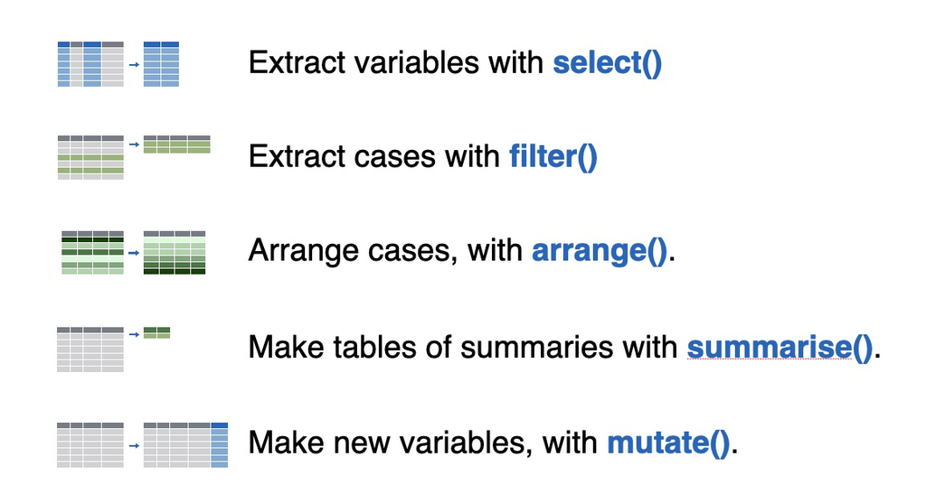